# Proyecto final secuenciación de RNA: Equipo 3

**Bioinformática y estadística 2**

Fecha de entrega: 20 de Mayo del 2025

### Elaborado por:

- Equipo: 3

- Integrantes:

• Diana Barrientos González (dbarrientos): diana.barrientos.glz@gmail.com

• Román Cervantes Levario (rcervantes): ro.cerlev@gmail.com

• Jair Emiliano Contreras Rivera (jcontreras): jairivera322@gmail.com

## Descripción de los datos

**Título del artículo original:** Impact of spaceflight and artificial gravity on sulfur metabolism in mouse liver: sulfur metabolomic and transcriptomic analysis

**Elaborado por:** Ryo Kurosawa, Ryota Sugimoto, Hiroe Imai, Kohei Atsuji, Koji Yamada, Yusuke Kawano, Iwao Ohtsu, Kengo Suzuki

**Publicado el:** 8 de Noviembre del 2021

Tabla 1: Detalles del Bioproyecto y características de las muestras

```r
library(DT)
tabla_info <- data.frame(
  Descripcion = c(
    "Bioproject",
    "Especie",
    "Tipo de bibliotecas",
    "Método de selección",
    "Número de transcriptomas",
    "Número de réplicas biológicas",
    "Secuenciador empleado",
    "Profundidad de secuenciación de cada transcriptoma",
    "Tamaño de las lecturas",
    "Artículo científico"
  ),

  Informacion = c(
    '<a href="https://www.ncbi.nlm.nih.gov/bioproject/PRJNA1005192" target="_blank">PRJNA1005192</a>',
    "Mus musculus",
    "paired-end",
    "Poly(A) mRNA Magnetic Isolation Module",
    "9",
    "3 réplicas biológicas para 3 condiciones",
    "Illumina NovaSeq 6000",
    "14.4 M seq a 25.9 M seq",
    "300 AvgSpotLen",
    "Kurosawa R, Sugimoto R, Imai H, Atsuji K, Yamada K, Kawano Y, Ohtsu I, Suzuki K. Impact of spaceflight and artificial gravity on sulfur metabolism in mouse liver: sulfur metabolomic and transcriptomic analysis. Sci Rep. 2021 Nov 8;11(1):21786. doi: 10.1038/s41598-021-01129-1. PMID: 34750416; PMCID: PMC8575787"
  ),

  stringsAsFactors = FALSE
)

datatable(
  tabla_info,
  rownames = FALSE,
  escape = FALSE,
  options = list(
    pageLength = 10,
    searching = FALSE,
    paging = FALSE,
    dom = 't'
  )
)
```

| Descripcion | Informacion |
| --- | --- |
| Bioproject | PRJNA1005192 |
| Especie | Mus musculus |
| Tipo de bibliotecas | paired-end |
| Método de selección | Poly(A) mRNA Magnetic Isolation Module |
| Número de transcriptomas | 9 |
| Número de réplicas biológicas | 3 réplicas biológicas para 3 condiciones |
| Secuenciador empleado | Illumina NovaSeq 6000 |
| Profundidad de secuenciación de cada transcriptoma | 14.4 M seq a 25.9 M seq |
| Tamaño de las lecturas | 300 AvgSpotLen |
| Artículo científico | Kurosawa R, Sugimoto R, Imai H, Atsuji K, Yamada K, Kawano Y, Ohtsu I, Suzuki K. Impact of spaceflight and artificial gravity on sulfur metabolism in mouse liver: sulfur metabolomic and transcriptomic… |

El artículo de “Impact of spaceflight and artificial gravity on sulfur metabolism in mouse liver: sulfur metabolomic and transcriptomic analysis (house mouse)” analiza el daño hepático por vuelos espaciales, debido al estrés oxidativo causado por el entorno espacial. El organismo modelo *Mus musculus*, del strain C57BL/6J fue utilizado bajo tres condiciones:

- La primera a bordo de la estación espacial internacional (MG mice)
- La segunda sometidos a gravedad terrestre artificial (A1G mice)
- Comparados con un grupo de control de ratones en la Tierra (GC mice)

Se usó RNA-seq para estudiar la *upregulation* de un conjunto de genes relacionados al estrés oxidativo y el metabolismo del azufre.

Para fines de esta práctica, se seleccionaron las muestras correspondientes las tres condiciones, las cuales se presentan en la Tabla 2.

Tabla 2: Distribución de las muestras y réplicas biológicas

| ID réplica biológica | Grupo | Condición | BioSample | SRR ID |
| --- | --- | --- | --- | --- |
| 36978221 | GC mice | Control en la Tierra | SAMN36978221_GC | SRR25629473 |
| 36978220 | GC mice | Control en la Tierra | SAMN36978220_GC | SRR25629472 |
| 36978219 | GC mice | Control en la Tierra | SAMN36978219_GC | SRR25629471 |
| 36978218 | A1G mice | Gravedad terrestre artificial | SAMN36978218_A1G | SRR25629470 |
| 36978217 | A1G mice | Gravedad terrestre artificial | SAMN36978217_A1G | SRR25629469 |
| 36978216 | A1G mice | Gravedad terrestre artificial | SAMN36978216_A1G | SRR25629468 |
| 36978215 | MG mice | Microgravedad en el espacio | SAMN36978215_MG | SRR25629467 |
| 36978214 | MG mice | Microgravedad en el espacio | SAMN36978214_MG | SRR25629466 |
| 36978213 | MG mice | Microgravedad en el espacio | SAMN36978213_MG | SRR25629465 |

## Abstract y resumen de nuestro trabajo

Para este análisis de RNA-seq, se compararon transcriptomas hepáticos de ratones bajo tres condiciones: microgravedad real (espacio, 30 días), gravedad artificial terrestre (también en el espacio durante 30 días) y un grupo control en Tierra. Se analizaron datos obtenidos del BioProject PRJNA1005192, compuesto por nueve transcriptomas de hígado paired-end de mRNA enriquecida por Poly(A) y secuenciada con Illumina NovaSeq 6000, con tres réplicas biológicas por condición y una profundidad de secuenciación de entre 14.4 y 25.9 millones de lecturas de 300 pb promedio.

El procesamiento se realizó mediante TrimGalore para control de calidad y recorte de adaptadores, combinando FastQC y Cutadapt de forma automatizada. La cuantificación se realizó con Salmon mediante pseudoalineamiento basado en índices de k-meros, lo que permite una estimación precisa de la expresión sin alineamiento base a base, reduciendo el tiempo de cómputo significativamente.

Ambas herramientas fueron integradas en un pipeline reproducible con Nextflow. Posteriormente, se aplicó una corrección de batch effect con limma mediante regresión lineal sobre la matriz de expresión normalizada. El análisis de expresión diferencial se realizó con DESeq2, herramienta basada en un modelo binomial negativo diseñada para datos de conteos de RNA-seq con robusto desempeño en experimentos con pocas réplicas. Finalmente, el análisis de enriquecimiento funcional se realizó con g:Profiler consultando Gene Ontology y KEGG para identificar procesos biológicos y vías metabólicas enriquecidas.

El análisis identificó cambios en la expresión génica asociados a la adaptación fisiológica hepática frente a condiciones de microgravedad y gravedad artificial, con alteraciones en vías relacionadas a funciones hepáticas centrales. Adicionalmente, se observó una modificación en la expresión de genes vinculados a la producción de antioxidantes, en aparente compensación al agotamiento de compuestos de azufre, evidenciando el impacto de los cambios gravitacionales sobre la función hepática.

## Control de calidad de las secuencias antes del trimming

#### Calidad de las secuencias en muestras GC, A1G y MG mice

Se analizó la calidad de las secuencias en los datos crudos, obteniendo un contenido de GC en un rango de 48 - 50% , con una distribución normal y una profundidad de lectura en un rango de 14.4 M a 25.9 M secuencias.

Las muestras presentan una calidad óptima, con valores dentro de la zona verde y un puntaje Phred de 30 en todas las muestras.

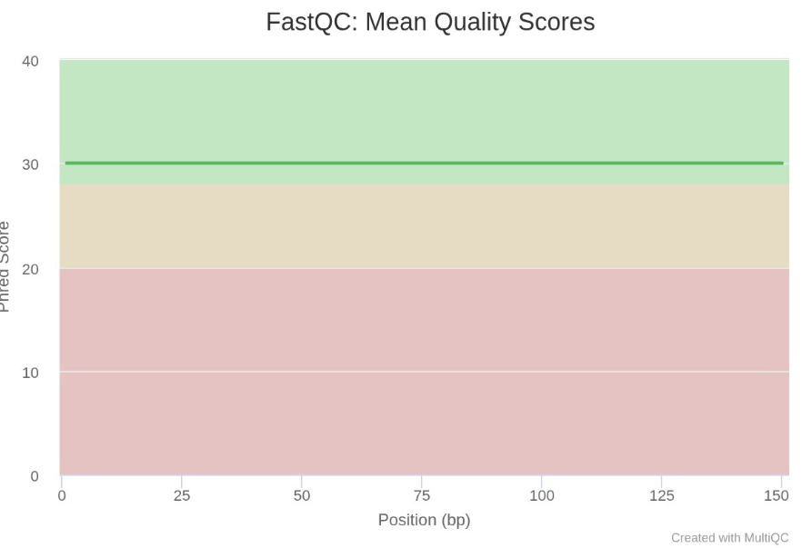

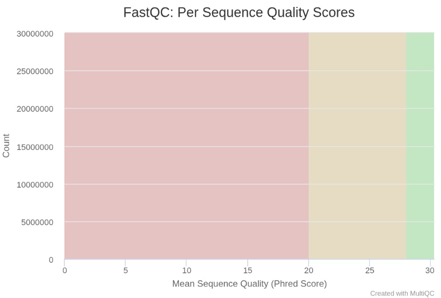

#### Proporción de cada base por posición

En la gráfica “Per Sequence Quality Scores”, la calidad está en 30 para todas las lecturas. Esto es lo esperado debido a que el secuenciador Illumina NovaSeq 6000 tiene una calidad muy alta.

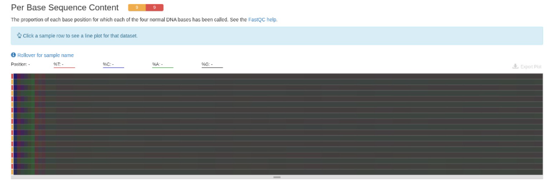

#### Variaciones en el porcentaje de %GC en todas las muestras

Esta gráfica está dentro de lo esperado para un experimento de RNA seq, se observa homogeneidad a lo largo de la gráfica, excepto al inicio, lo cual es lo esperado debido al ruido biológico.

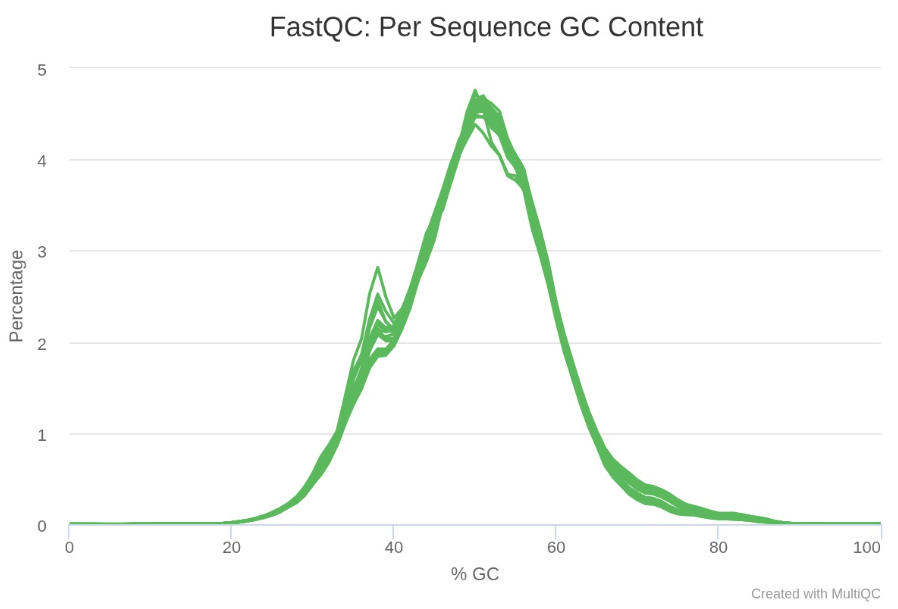

#### Contenido de N por base

En el mRNA de ratón, el contenido de GC esperado debería estar cercano a 50%, debido a que estamos capturando exones y genes expresados, lo cual puede aumentar la proporción esperada. Se observa un ligero pico lo cual puede ser contaminacion. Esta se espera eliminar posterior al pseudoalineamiento por lo que no es nada para preocuparse

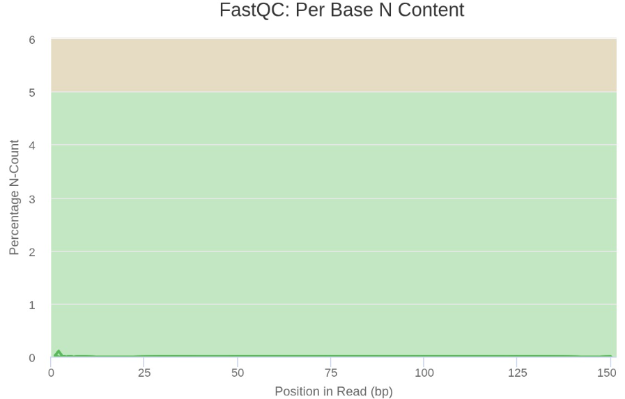

#### Distribución de secuencias duplicadas y adaptadores

El secuenciador identificó correctamente las bases en todas las posiciones de la secuenciación, por lo cual no hay ninguna posición donde la secuencia sea desconocida.

Distribución de la longitud de secuencias: todas las muestras tienen una longitud de 150 bp, lo cual es lo esperado considerando que son paired-end. En total con ambas lecturas, obtendríamos la longitud de 300 bp.

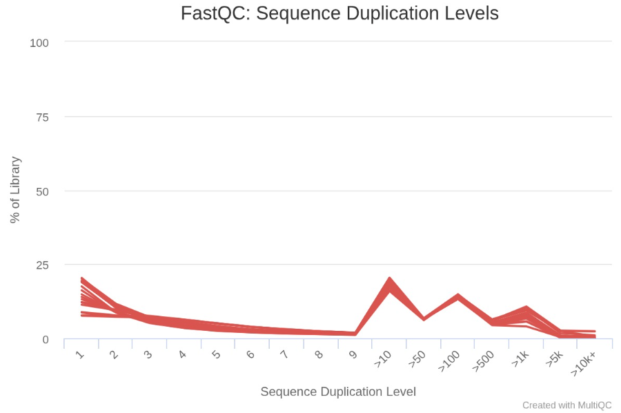

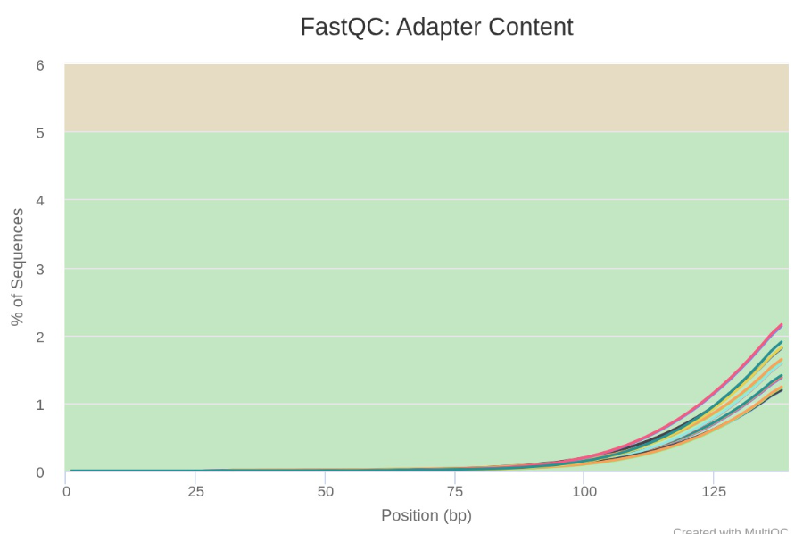

Se observa la distribución del contenido de los adaptadores, esto es normal porque no se he hecho trimming. Se observará esta grafica posterior a hacerlo y tener especial cuidado.

#### Conclusión

Los indicadores de MultiQC muestran una alta calidad, por lo cual los datos son adecuados para continuar con el procesamiento y análisis posterior. Las secuencias tienen una buena calidad en general, con calidad de secuencia de 30 en el Phred score y un contenido de %GC adecuado, además de que los nucleótidos no mapeados son prácticamente nulos. Aunque se observa picos en los niveles de secuencias duplicadas, el diseño del experimento sugiere que es normal (polyA y sobreexpresión en hígado).

## Diagrama de flujo

Vamos a seguir los siguientes pasos:

1. Letura y anotación de metadatos
2. Descarga de las secuencias crudas
3. Control de calidad de las muestras
4. Usar nextflow (nf core rna seq) para relizar el trimming y pseudoalineamiento
5. Importación de datos a R
6. PCA y corrección de batch
7. Análisis de expresión diferencial
8. Análisis de enriquecimiento de los genes diferencialmente expresados

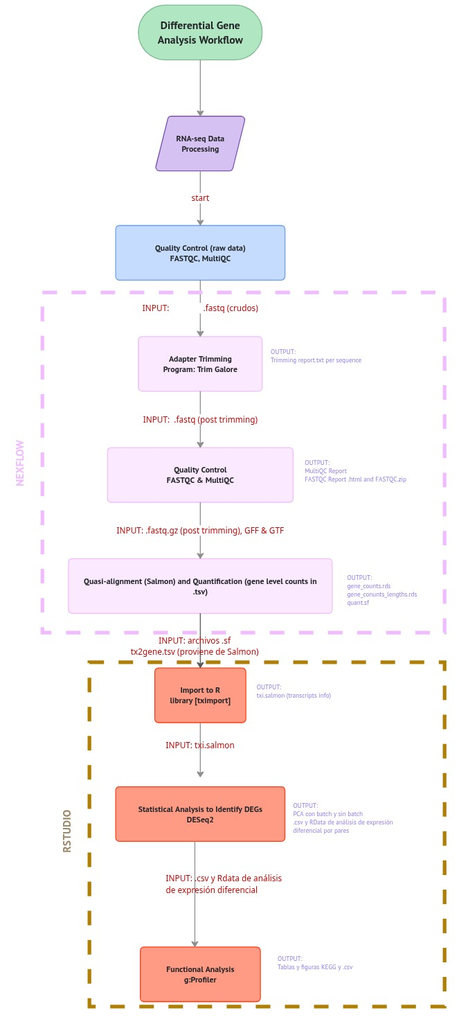

## Descripción de nuestras rutas

**Buenas prácticas de bioinformática**

Las carpetas siguen la siguiente estructura:

**Equipo3/** (`/mnt/data/bioinfo-estadistica-2/RNAseq_2026/equipos/Equipo3`): Directorio de trabajo principal donde se encuentra el proyecto.

- **data/** (`/mnt/data/bioinfo-estadistica-2/RNAseq_2026/equipos/Equipo3/data`): En esta carpeta se encuentran los datos de las secuencias de RNA e información relacionada.
  - **raw/** (`/mnt/data/bioinfo-estadistica-2/RNAseq_2026/equipos/Equipo3/data/raw`): En esta carpeta se guardaron las secuencias crudas extraídas de [ENA](https://www.ebi.ac.uk/ena/browser/view/PRJNA1005192) usando el ID del bioproject.
  - **counts/** (`/mnt/data/bioinfo-estadistica-2/RNAseq_2026/equipos/Equipo3/data/counts``): En esta carpeta se encuentran los conteos de los transcritos normalizados
  - **PCA/** (`/mnt/data/bioinfo-estadistica-2/RNAseq_2026/equipos/Equipo3/data/PCA``): Este directorio contiene los gráficos del análisis de componentes principales antes y después de la corrección por batch
  - **DEG/**(`/mnt/data/bioinfo-estadistica-2/RNAseq_2026/equipos/Equipo3/data/DEG``): Esta carpeta contiene los resultados del análisis de expresión diferencial para cada grupo
  - **ORA/** (`/mnt/data/bioinfo-estadistica-2/RNAseq_2026/equipos/Equipo3/data/ORA``): Este directorio contiene los resultados del análisis de enriquecimiento para los genes diferencialmente expresados en formato `csv``
    - **figures/** (`/mnt/data/bioinfo-estadistica-2/RNAseq_2026/equipos/Equipo3/data/ORA/figures``): Esta carpeta contiene las gráficas Manhattan y los genes diferencialmente expresados para cada grupo
  - **metadata.txt**: Es un archivo de texto que contiene la información de la tabla 2.
  - **txi_salmon.RData**: Este archivo es un documento intermedio para importar los datos a R.
  - **TPM_matrix.csv** es la matriz de transcritos por millón para todas las muestras sin ningún procesamiento adicional
  - **processedTPM_matrix.csv**: Este documento es el numero de trasncritos por millón para todas las muestras analizadas, normalizado por Z-score y utilizado para hacer el PCA
  - **txi_salmon.RData:** Es el objeto de R generado por tximport que importa y contiene los resultados de cuantificación de Salmon para todas las muestras, sirviendo como input directo para DESeq2.
- **quality1/** (`/mnt/data/bioinfo-estadistica-2/RNAseq_2026/equipos/Equipo3/quality1`): Dentro de este directorio podemos encontrar los controles de calidad de las secuencias crudas.
  - **fastqc/** (`/mnt/data/bioinfo-estadistica-2/RNAseq_2026/equipos/Equipo3/quality1/fastqc`): Esta carpeta incluye los resultados de los controles de calidad para las secuencias individuales.
    - **html/** (`/mnt/data/bioinfo-estadistica-2/RNAseq_2026/equipos/Equipo3/quality1/fastqc/html)`: Engloba al reporte de los controles de calidad en formato `html`.
    - **fastqc_info/** (`/mnt/data/bioinfo-estadistica-2/RNAseq_2026/equipos/Equipo3/quality1/fastqc/fastqc_info`): Dentro de esta carpeta podemos encontrar información comprimida de los reportes de calidad.
  - **multiqc/** (`/mnt/data/bioinfo-estadistica-2/RNAseq_2026/equipos/Equipo3/quality1/multiqc`): Este directorio contiene la información resumida de los reportes de calidad de todas las secuencias crudas.
    - **multiqc_report.html**: En este archivo .html se encuentra el reporte de multiqc para todas las secuencias crudas.
    - **multiqc_data/** (`/mnt/data/bioinfo-estadistica-2/RNAseq_2026/equipos/Equipo3/quality1/multiqc/multiqc_data`): Dentro de esta carpeta se encuentra información relacionada de los multiqc.
- **quality2/** (`/mnt/data/bioinfo-estadistica-2/RNAseq_2026/equipos/Equipo3/quality2`): En esta carpeta podemos ver todos los outputs del control de calidad (trimming) y pseudoalineamiento (Salmon), que arrojó Nextflow. El funcionamiento del pipeline se explicará más adelante.
  - **fastqc/** (`/mnt/data/bioinfo-estadistica-2/RNAseq_2026/equipos/Equipo3/quality2/fastqc`): En esta carpeta se encuentra el control de calidad antes de hacer el trimming. Este reporte es idéntico al de **quality1/**, sin embargo no se eliminó para mantener la estructura del pipeline original.
  - **multiqc_trim/** (`/mnt/data/bioinfo-estadistica-2/RNAseq_2026/equipos/Equipo3/quality2/multiqc_trim`): Esta carpeta el reporte de las secuencias posterior a hacer el trimming. Dentro de esta se encuentra el archivo `.html` con el reporte y una carpeta con información de las estadísticas calculadas
  - **pipeline_info/** (`/mnt/data/bioinfo-estadistica-2/RNAseq_2026/equipos/Equipo3/quality2/pipeline_info`): Dentro de este directorio podemos encontrar información del pipeline ejecutado. Estos datos nos aseguran reproducibilidad y nos aseguran de que todo de corrió correctamente. Entre los procesos que podemos apreciar dentro de este se encuentran:
    - **software_versions.yml**: Información de las versiones del software y programas utilizados
    - **params_*.json**: Qué parámetros fueron utilizados para el pipeline
    - **execution_timeline_2026-XXX-XX-XX_XX.html**: Es una línea temporal sobre cuáles y cuántos procesos fueron ejecutados así como su duración
    - **execution_trace_2026-XXX-XX-XX_XX.txt**: Información sobre los procesos ejecutados
    - **execution_report_XXXX-XX-XX_XX.html**: Contiene un resumen de la corrida del pipeline
  - **trimgalore/** (`/mnt/data/bioinfo-estadistica-2/RNAseq_2026/equipos/Equipo3/quality2/trimgalore`): En esta carpeta podemos observar el reporte del trimming de las secuencias así como los fastqc post trimming de las secuencias.
    - **SAMPLE_X.fastq.gz_trimming_report.txt**: Estos archivos son reportes del trimming de cada secuencia. Este nos reporta el total de reads originales, reads en las que se encontraron adaptadores, bases removidas por mala calidad, reads conservadas y el total de bases restantes posterior al trimming.
    - **fastqc/** (`/mnt/data/bioinfo-estadistica-2/RNAseq_2026/equipos/Equipo3/quality2/trimgalore/fastqc`): Contiene el reporte de las secuencias posterior al trimming. Esta carpeta es el input de **multiqc_trim/**
  - **work/** (`/mnt/data/bioinfo-estadistica-2/RNAseq_2026/equipos/Equipo3/quality2/work`): Dentro de esta carpeta se guardan todos los archivos ejecutados durante el pipeline. Dentro de esta podemos encontrar las secuencias post trimming. Podemos encontrar sus rutas con el comando `find . -name "val.fq.gz"`
  - **salmon/** (`/mnt/data/bioinfo-estadistica-2/RNAseq_2026/equipos/Equipo3/quality2/salmon`): Este directorio engloba todo los outputs del pseudoalinemiento con Salmon. Nos dice la cuantificación de transcritos, abundancia, etc.
    - **SAMPLE_CONDITION/**: Estas carpetas contienen los resultados del pseudoalineamiento y conteo para una muestra. Cada muestra contiene una carpeta con su propio resultado del pseudoalinemiento. Cada una contiene:
      - **quant.sf**: Cuantificación y abundancia a nivel del transcrito
      - **quant.genes.sf**: Cuantificación y abundancia a nivel del gen
      - **aux_info/**: Contiene estadísticas y modelos usados por Salmon. El archivo más importante dentro de esta carpeta es meta_info.json el cual contiene los metadatos del pipeline (reads procesados, versión de Salmon, etc.)
      - Las carpetas restantes engloban información sobre el comando para correr Salmon (**cmd_info.json**), orientación de la librería (**lib_format_counts.json**), distribución de librerías mencionadas previamente (**libParams/**), además de warnings, errores y tiempos dentro de la carpeta (**logs/**)
    - **salmon.merged.gene_counts.tsv**: Este .tsv contiene el conteo de genes para todas las muestras.
    - **salmon.merged.gene_tpm.tsv**: Es una matriz con los transcritos por millón para todas las muestras.
    - **salmon.merged.transcript_counts.tsv**: Es un formato alterno que contiene los conteos de cada trascrito para todas las muestras
    - **salmon.merged.gene_lengths.tsv**: Contiene la longitud de los genes para todas las muestras
    - **salmon.merged.transcript_lengths.tsv**: Contiene la longitud de los transcritos para todas las muestras
    - **tx2gene.tsv**: Muestra la relación entre transcritos y gen
- **scripts/** (`/mnt/data/bioinfo-estadistica-2/RNAseq_2026/equipos/Equipo3/scripts``): Este directorio contiene todos los scripts para realizar el análisis.
  - **download_data/** (`/mnt/data/bioinfo-estadistica-2/RNAseq_2026/equipos/Equipo3/scripts/download_data/`): Contiene el script utilizado para descargar los transcritos crudos
  - **rna_nextflow/** (`/mnt/data/bioinfo-estadistica-2/RNAseq_2026/equipos/Equipo3/scripts/rna_nextflow/)` : Dentro de esta carpeta se encuentran los scripts utilizados para correr el trimming y el pseudoalinemiento usando nextflow
  - **normalizacion_salmon/** (`/mnt/data/bioinfo-estadistica-2/RNAseq_2026/equipos/Equipo3/scripts/normalizacion_salmon`): Dendro de esta carpeta podremos encontrar dos scripts
    - normalizacion_salmon: Este script sirve se enfoca en importar los datos usando tximport
    - deseq2: Este código integra información de el script anterior para hacer el PCA, la corrección de batch y el análisis de expresión diferencial
  - **gene_ontology/** (`/mnt/data/bioinfo-estadistica-2/RNAseq_2026/equipos/Equipo3/scripts/gene_ontology`): Este script contiene el código para hacer el análisis de enriquecimiento
  - **outlogs/** (`/mnt/data/bioinfo-estadistica-2/RNAseq_2026/equipos/Equipo3/scripts/out_logs`): Contiene los archivos de salida estándar `.out` y los archivos de error estándar `.err` que contiene los errores o warnings de cada script corrido.
    - `DownloadData_1397.err` y `DownloadData_1397.out` corresponden al script de `download_Data.sh` de la carpeta `download_data/`
    - `deseq2_1818.err` y `deseq2_1818.out` corresponden al script de `deseq2.r` de la carpeta `normalizacion_salmon/`
    - `normalizacion_1792.err` y `normalizacion_1792.out` corresponden al script de `deseq2.r` de la carpeta `normalizacion_salmon/`
    - `rnaseq_1478.err` y `rnaseq_1478.out` corresponden al script de `rna_nextflow.sh` de la carpeta `rna_nextflow/`
    - `gene_ontology_1817.err` y `gene_ontology_1817.out` corresponden al script de `gene_ontology.sh` de la carpeta `gene_ontology/`
  - **samplesheet.csv**: Incluye el documento input de nextflow, el cual se explicará abajo

#### Documentación de nextflow

Se utilizó nextflow para tener control sobre el flujo del trabajo. Este nos permite automatizar y guardar los procedimientos en caso de que el trabajo se detenga. Para realizar la corrección con este programa tenemos que especificar distintos parámetros:

- Se necesita especificar la ruta de los outputs, uso de memoria, computadoras e inputs
- Para eliminar los adaptadores, decidimos usar Trimgalore: Este programa realiza la tarea de forma eficiente además de recortar secuencias de mala calidad
- Dado el tamaño y la cantidad de nuestras muestras, un alineamiento iba a ser muy costoso computacionalmente, por lo que se decidió hacer un pseudoalineamiento utilizando Salmon, un programa con buen desempeño y que adicionalmente tiene un programa de corrección de sesgos de GC
- Para alinear, especificamos que se buscara el genoma de referencia predefinida para el genoma del ratón
- Algunas opciones incluidas para evitar errores fueron fijar Java 11 en el entorno de Nextflow y fijar una versión del pipeline de nf-core compatible con Java 11 (algunas requerían versiones superiores que no estaban disponibles)

```bash
#!/bin/bash
#SBATCH --job-name=rnaseq_equipo3
#SBATCH --output=/mnt/data/bioinfo-estadistica-2/RNAseq_2026/equipos/Equipo3/scripts/out_logs/rnaseq_%j.out
#SBATCH --error=/mnt/data/bioinfo-estadistica-2/RNAseq_2026/equipos/Equipo3/scripts/out_logs/rnaseq_%j.err
#SBATCH --time=24:00:00
#SBATCH --cpus-per-task=2
#SBATCH --mem=8G

export JAVA_HOME=/usr/lib/jvm/java-11-openjdk-11.0.25.0.9-7.el9.x86_64
export PATH=$JAVA_HOME/bin:$PATH

module load nextflow/23.04.1
module load singularity/3.7.0

nextflow run nf-core/rnaseq \
    -revision 3.14.0 \
    -profile singularity \
    --input /mnt/data/bioinfo-estadistica-2/RNAseq_2026/equipos/Equipo3/scripts/samplesheet.csv \
    --outdir /mnt/data/bioinfo-estadistica-2/RNAseq_2026/equipos/Equipo3/quality2 \
    --genome GRCm38 \
    --pseudo_aligner salmon \
    --skip_alignment \
    --trimmer trimgalore \
    --extra_salmon_quant_args '--gcBias true' \
    -resume
```

Explicación del código:

Refiriendo al documento de input, se tiene que crear un documento csv que contenga la información de la ruta de las secuencias para cada muestra. Así como especificar la orientación de la transcripción, en nuestro caso lo fijamos a automático.

```bash
sample,fastq_1,fastq_2,strandedness
SAMN36978221_GC,/mnt/data/bioinfo-estadistica-2/RNAseq_2026/equipos/Equipo3/data/raw/SRR25629473_1.fastq.gz,/mnt/data/bioinfo-estadistica-2/RNAseq_2026/equipos/Equipo3/data/raw/SRR25629473_2.fastq.gz,auto
SAMN36978220_GC,/mnt/data/bioinfo-estadistica-2/RNAseq_2026/equipos/Equipo3/data/raw/SRR25629472_1.fastq.gz,/mnt/data/bioinfo-estadistica-2/RNAseq_2026/equipos/Equipo3/data/raw/SRR25629472_2.fastq.gz,auto
SAMN36978219_GC,/mnt/data/bioinfo-estadistica-2/RNAseq_2026/equipos/Equipo3/data/raw/SRR25629471_1.fastq.gz,/mnt/data/bioinfo-estadistica-2/RNAseq_2026/equipos/Equipo3/data/raw/SRR25629471_2.fastq.gz,auto
SAMN36978218_A1G,/mnt/data/bioinfo-estadistica-2/RNAseq_2026/equipos/Equipo3/data/raw/SRR25629470_1.fastq.gz,/mnt/data/bioinfo-estadistica-2/RNAseq_2026/equipos/Equipo3/data/raw/SRR25629470_2.fastq.gz,auto
SAMN36978217_A1G,/mnt/data/bioinfo-estadistica-2/RNAseq_2026/equipos/Equipo3/data/raw/SRR25629469_1.fastq.gz,/mnt/data/bioinfo-estadistica-2/RNAseq_2026/equipos/Equipo3/data/raw/SRR25629469_2.fastq.gz,auto
SAMN36978216_A1G,/mnt/data/bioinfo-estadistica-2/RNAseq_2026/equipos/Equipo3/data/raw/SRR25629468_1.fastq.gz,/mnt/data/bioinfo-estadistica-2/RNAseq_2026/equipos/Equipo3/data/raw/SRR25629468_2.fastq.gz,auto
SAMN36978215_MG,/mnt/data/bioinfo-estadistica-2/RNAseq_2026/equipos/Equipo3/data/raw/SRR25629467_1.fastq.gz,/mnt/data/bioinfo-estadistica-2/RNAseq_2026/equipos/Equipo3/data/raw/SRR25629467_2.fastq.gz,auto
SAMN36978214_MG,/mnt/data/bioinfo-estadistica-2/RNAseq_2026/equipos/Equipo3/data/raw/SRR25629466_1.fastq.gz,/mnt/data/bioinfo-estadistica-2/RNAseq_2026/equipos/Equipo3/data/raw/SRR25629466_2.fastq.gz,auto
SAMN36978213_MG,/mnt/data/bioinfo-estadistica-2/RNAseq_2026/equipos/Equipo3/data/raw/SRR25629465_1.fastq.gz,/mnt/data/bioinfo-estadistica-2/RNAseq_2026/equipos/Equipo3/data/raw/SRR25629465_2.fastq.gz,auto
```

Todos los resultados se van a guardar en **quality2/** (`/mnt/data/bioinfo-estadistica-2/RNAseq_2026/equipos/Equipo3/quality2`) la estructura de las carpetas junto con cada salida fue previamente explicada. A continuación se mencionan de forma breve los outputs:

Del control de calidad antes del trimming se obtienen reportes individuales por muestra en formato HTML además de un reporte global de MultiQC.

Del trimming con TrimGalore se obtiene por muestra un reporte de texto con el total de reads originales, el porcentaje de reads con adaptadores detectados, las bases removidas por baja calidad, las reads conservadas y el total de bases restantes. Además, se generan los FastQC resumidos un segundo reporte de MultiQC.

Del pseudoalineamiento con Salmon se obtiene por muestra un archivo quant.sf con la abundancia y conteo a nivel de transcrito y un quant.genes.sf a nivel de gen además de matrices como TPM, longitudes de genes y transcritos para todas las muestras, además del archivo tx2gene.tsv con la relación transcrito-gen. Finalmente se incluye información sobre la trazabilidad del pipeline, como versiones, opciones o errores.

## MultiQC posterior a la limpieza

En general, la calidad de las secuencias se mantuvo. el contenido de %GC es similar en todas las muestras, manteniendo el rango entre 48-50%. De igual manera, el Phred Score es de 30 en toda la secuencia.

[figure not shown]

El único problema que podría haber es con el pico que se observa en el contenido de GC por secuencia. Mientras el promedio está cerca de 50%, se observa otro pico cerca de 37-38% de GC. Sin embargo, esta contaminación no debería preocuparnos tanto, ya que al momento de hacer el alineamiento del ratón, las secuencias que no correspondan (de la contaminación) no se alinearán.

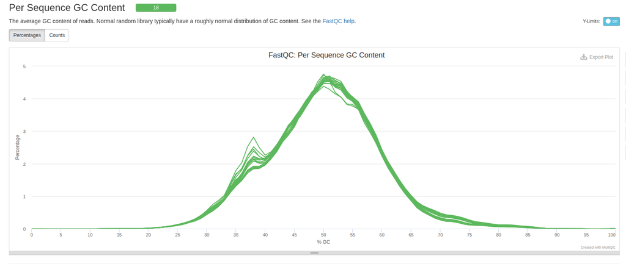

Podemos observar que la gráfica de los niveles de secuencias duplicadas también se mantuvieron.

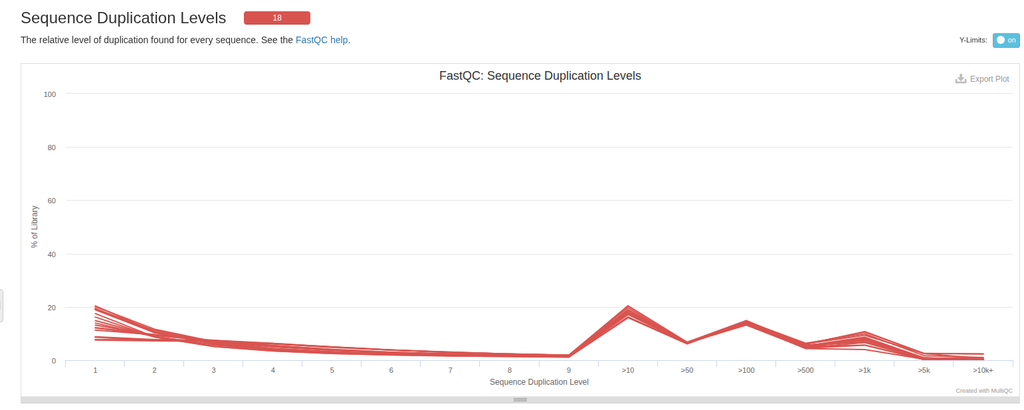

Por otro lado, el reporte muestra que se eliminaron correctamente los adaptadores, ya que no se encontraron muestras con contaminación de adaptadores ni con secuencias sobrerrepresentadas.

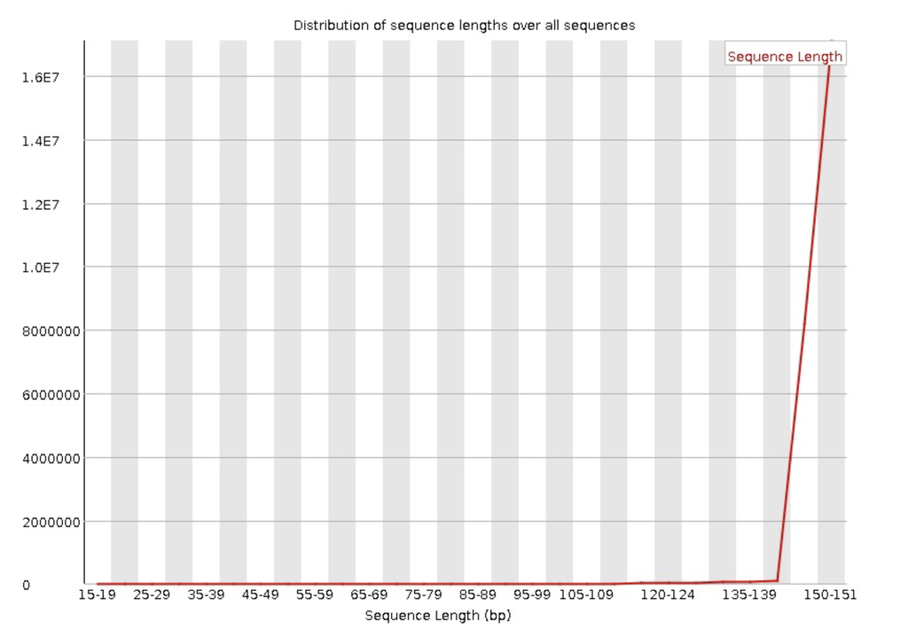

## Importación de datos en R

Se realizó el siguiente script para la importación de los datos. Se usó la libreria tximport junto con deseq para importar los datos a R

```bash
GNU nano 5.6.1                                                                              normalizacion_salmon.r
# Paquetes
library(tximport)
library(DESeq2)
# Definimos la ruta
ruta <- "/mnt/data/bioinfo-estadistica-2/RNAseq_2026/equipos/Equipo3/quality2/salmon"
metadata <- read.csv("/mnt/data/bioinfo-estadistica-2/RNAseq_2026/equipos/Equipo3/data/metadata.csv", header = TRUE)
metadata$folder_name <- metadata$sample_ID

# Buscamos los quant.sf
archivos_sf <- file.path(ruta, metadata$folder_name, "quant.sf")

# Extraemos el nombre SRR de la ruta
nombres_srr <- basename(dirname(archivos_sf))
names(archivos_sf) <- nombres_srr
archivos_sf

# Importamos con tximport
tx2gene <- read.table(
  "/mnt/data/bioinfo-estadistica-2/RNAseq_2026/equipos/Equipo3/quality2/salmon/tx2gene.tsv",
  header = FALSE,
  sep    = "\t",
  stringsAsFactors = FALSE
)

tx2gene <- tx2gene[,1:2]

colnames(tx2gene) <- c("TXNAME", "GENEID")

txi.salmon <- tximport(
  archivos_sf,
  type           = "salmon",
  ignoreTxVersion = TRUE,
  ignoreAfterBar  = TRUE,
  tx2gene = tx2gene
)

# Verificamos
names(txi.salmon)

# Imprimimos
all_transcripts <- rownames(txi.salmon$abundance)
length(unique(all_transcripts))

#GUARDAR TXI PARA DESEQ2
outdir <- "/mnt/data/bioinfo-estadistica-2/RNAseq_2026/equipos/Equipo3/data/"

save(txi.salmon, file = paste0(outdir, "txi_salmon.RData"))
message(" txi.salmon guardado en ", outdir, "txi_salmon.RData")
```

A partir de esto se obtuvo un total de 44677 transcritos.

Dimensión del dataset: 109616 3

# Análisis de componentes principales

### PCA antes de corrección

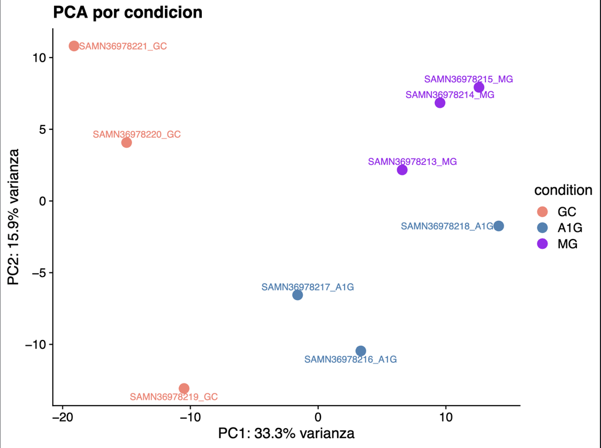

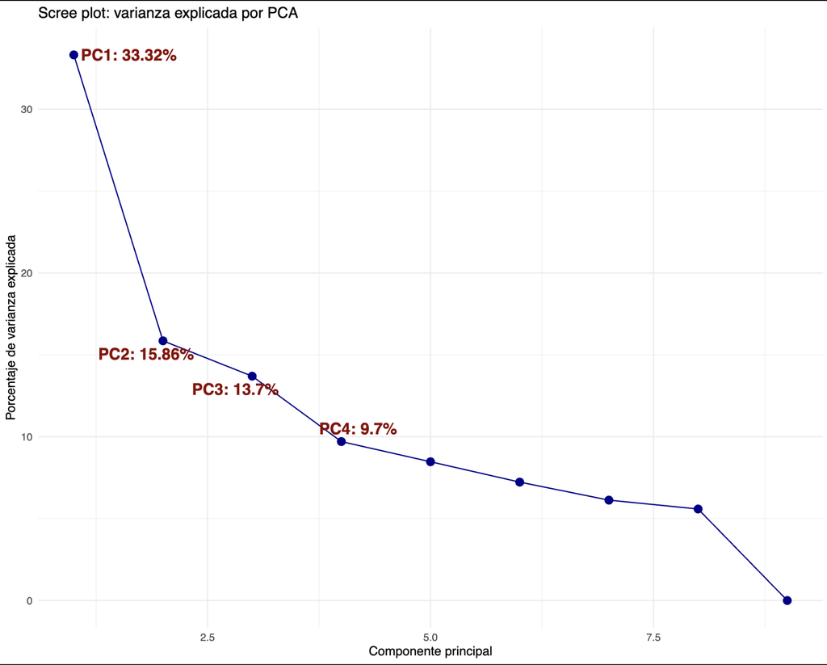

Con el objetivo de optimizar la precisión del análisis, se procedió a realizar una corrección de batch effect, por medio de la librería Limma. Aunque el agrupamiento inicial era aceptable, tras este proceso de corrección, los clusters en el PCA se visualizaron de manera mucho más compacta y definida. Con esto se demuestra que la variación tenga una explicación biológica y no se deba a ruido o a variación en las corridas de secuenciación. La efectividad de esta corrección se observa en el aumento de la varianza explicada por los componentes: el valor de la PC1 ascendió del 33.3% al 46%, lo que demuestra que, tras eliminar el ruido técnico, la componente principal captura una mayor proporción de la variabilidad biológica. Es importante notar que, si bien el scree plot todavía muestra los mismos valores en la varianza, el análisis del PCA corregido confirma visualmente una mejora en la agrupación de los datos

### PCA después de la corrección

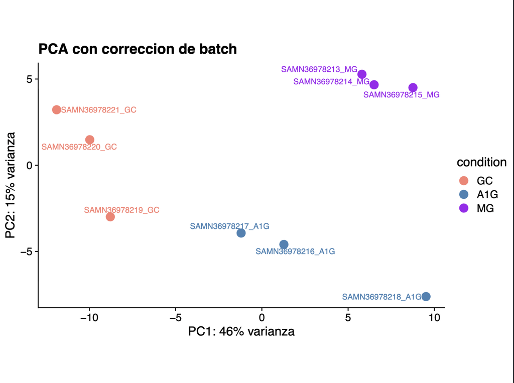

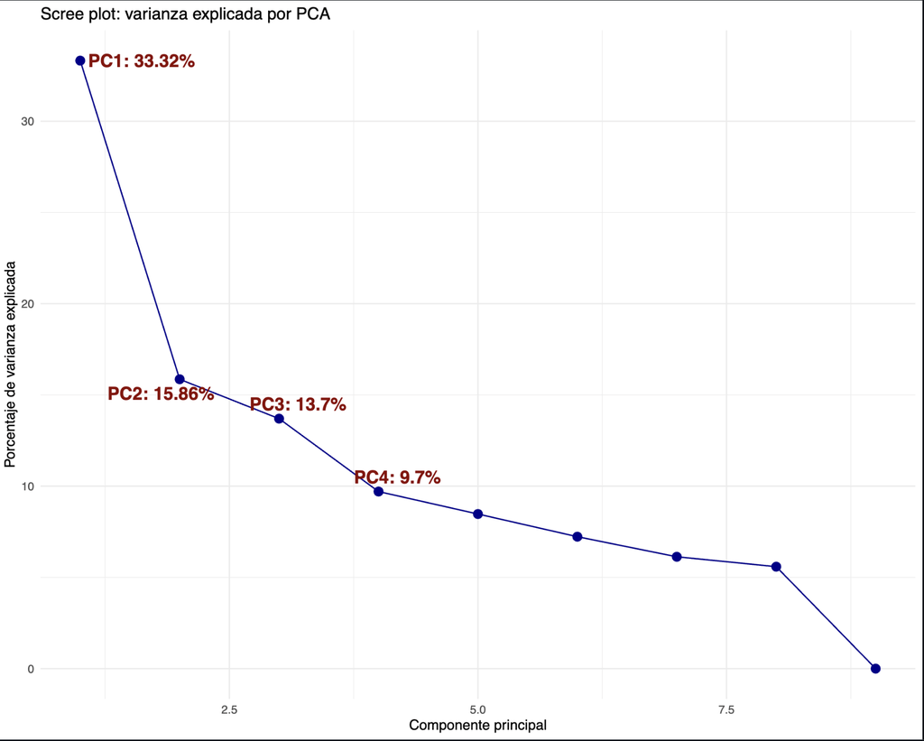

En conclusión, la aplicación de la corrección de batch permitió reducir el ruido técnico, logrando que los grupos experimentales se agruparan mejor y facilitando una interpretación más limpia de los cambios en la expresión génica.

### PCA con clusters denotados

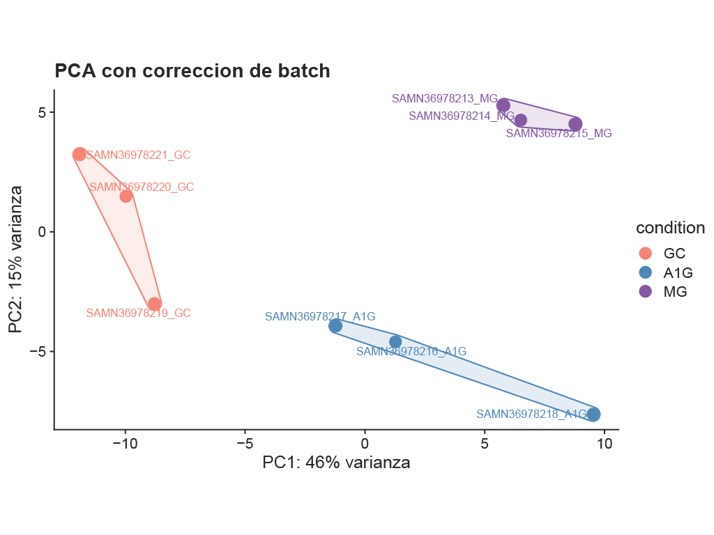

## Análisis de expresión diferencial y análisis de enriquecimiento

Posterior a corregir el el batch effect, se hizo un análisis de expresión diferencial para encontrar genes diferencialmente expresados en estos grupos. Dado que tenemos 3, se realizarán 3 analisis para las distintas combinaciones de grupos: A1G_vs_GC, MG_vs_A1G, MG_vs_GC. Se utilizó un nivel de significancia de un p-value corrected > 0.05. Además de buscar solo genes los cuales estén diferencialmente expresados en más o menos dos unidades. A continuación se reportan los resultados:

- Para A1G_vs_GC se encontraron 21 genes significativos diferencialmente expresados
- Para MG_vs_A1G se encontraron se encontraron 3 genes significativos diferencialmente expresados. Esto será un dato interesante para la discusión
- Finalmente, para MG_vs_GC se encontraron 67 genes significativos diferencialmente expresados

**Para A1G vs GC**

Resultados del análisis de enriquecimiento para los genes diferencialmente expresados sobreregulados entre ratones en la estación espacial internacional y en la Tierra, la ruta que más predomina es el metabolismo del retinol

[figure not shown]

Resultados del análisis de enriquecimiento para genes diferencielmente expresados subregulados entre ratones en la estación espacial internacional y en la Tierra, observamos que mayormente predominan son relacionadas a la biosíntesis de los lípidos

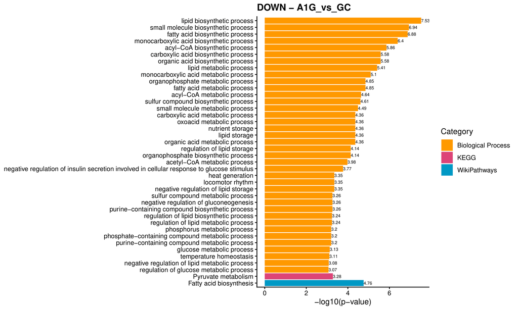

Resultados del Manhattan plot comparando genes sobreregulados de los subrregulados. Mientras más arriba se encuentren en el eje, más significativos son y los categoriza según las bases de datos `GO:BP = Gene Ontology Biological Process`, `KEGG = pathways metabólicos/señalización`, `REAC = Reactome`

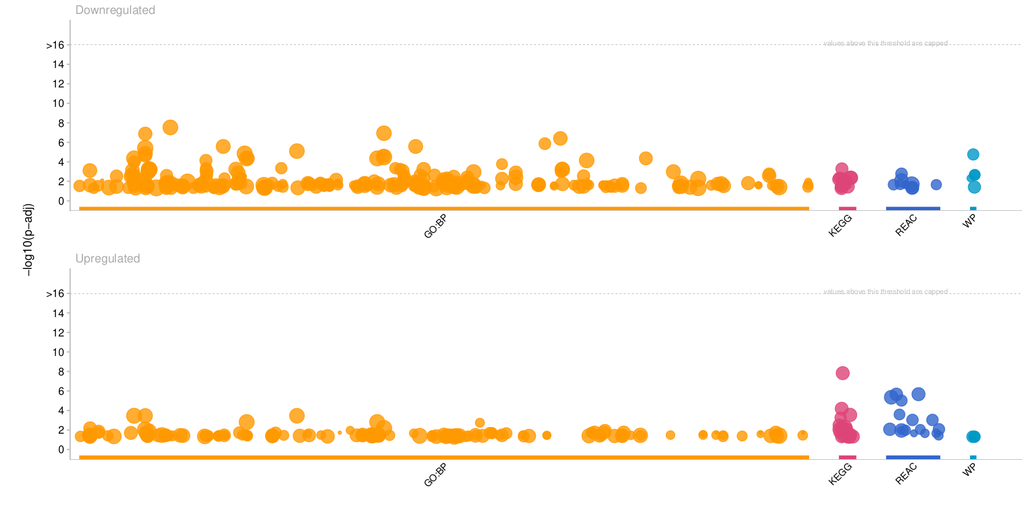

**Para MG_vs_A1G**

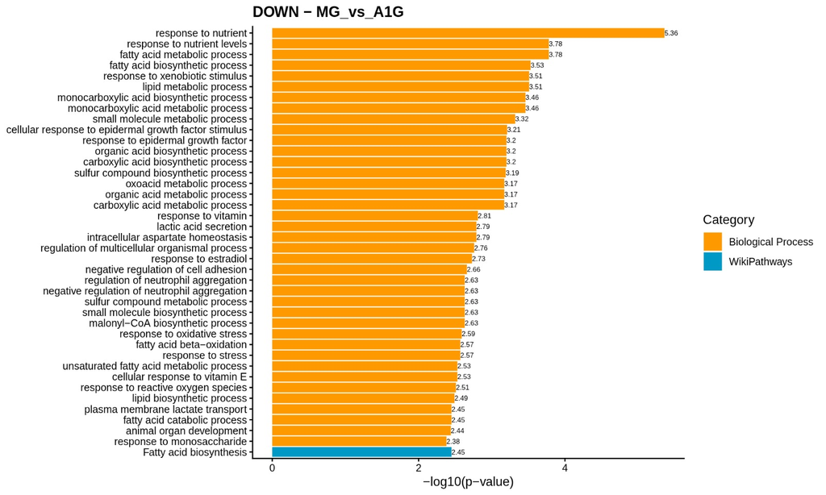

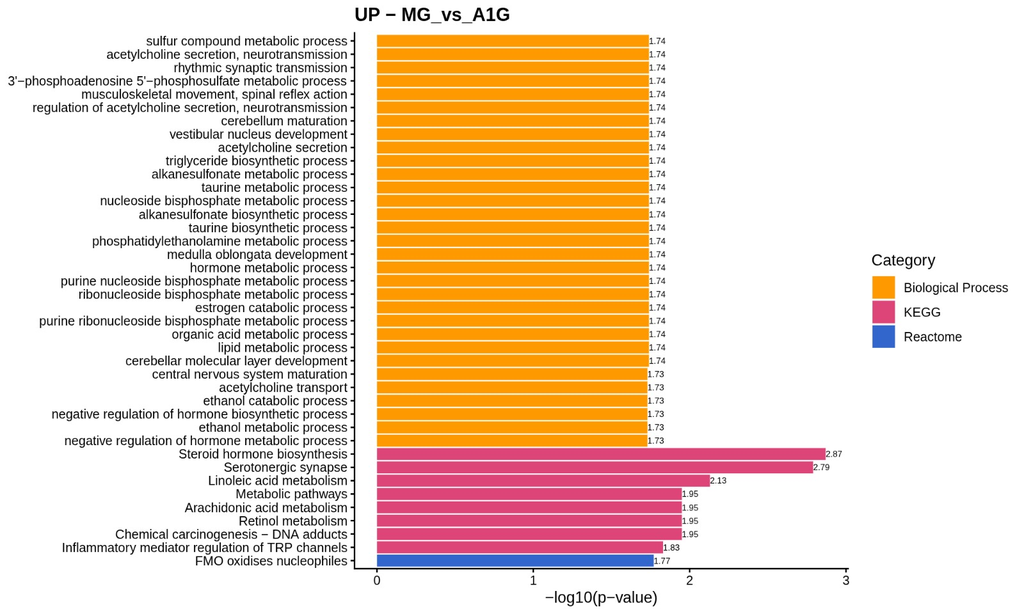

Resultados del Manhattan plot comparando genes sobreregulados de los subrregulados. Mientras más arriba se encuentren en el eje, más significativos son y los categoriza según las bases de datos `GO:BP = Gene Ontology Biological Process`, `KEGG = pathways metabólicos/señalización`, `REAC = Reactome`

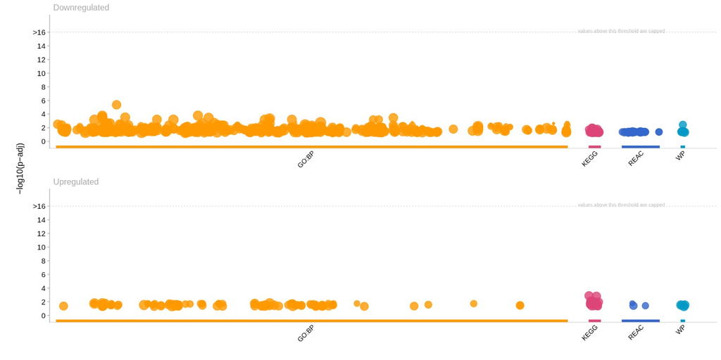

**Para MG_vs_GC**

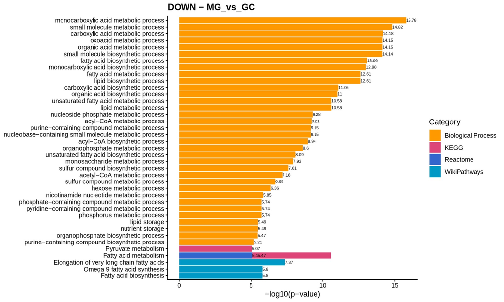

Resultados del análisis de enriquecimiento para genes diferencielmente expresados sobreregulados entre ratones entre la Tierra y microgravedad

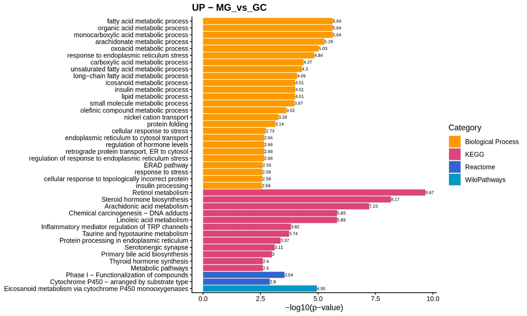

Resultados del Manhattan plot comparando genes sobreregulados de los subrregulados. Mientras más arriba se encuentren en el eje, más significativos son y los categoriza según las bases de datos `GO:BP = Gene Ontology Biological Process`, `KEGG = pathways metabólicos/señalización`, `REAC = Reactome`

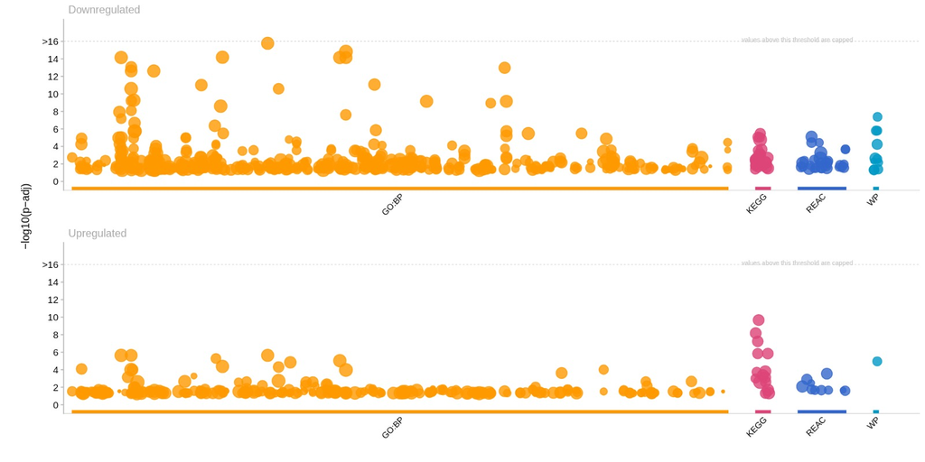

# Discusión de los resultados

Tras el análisis de la expresión de genes y los resultados del paper, se observa cómo el viaje al espacio provoca un gran estrés a los seres vivos, particularmente para el hígado. Como se menciona en el artículo, el hígado es el órgano más afectado y con mayor expresión diferencial de genes al someterse a viajes espaciales.

Tener grupos de A1G y de MG, ayuda a separar el efecto de la microgravedad y del viaje espacial, ya que el grupo A1G sufrió estrés por estar en el espacio, pero no se vio muy afectado por la gravedad. Por un lado, en el grupo de A1G se encontraba subexpresado el metabolismo hepático de los lípidos, posiblemente debido al estrés oxidativo. Además, los resultados hacen sentido cuando se analizan los genes sobreexpresados, ya que el principal de ellos es el metabolismo de retinoides, asociado a la detoxificación hepática. Esto se debe a que los radicales libres en el espacio obligan al organismo a buscar medidas de detoxificación.

En este caso, se encuentra sobreexpresada la síntesis de compuestos de azufre, por lo que se podría concluir que la gravedad tiene mayor efecto en la producción y gasto de azufre, mientras que las condiciones espaciales, con mayor cantidad de radicales libres, provocan que haya un aumento del metabolismo y detoxificación del cuerpo. Por lo tanto, es probable que los cambios metabólicos en los compuestos de azufre se deban a la baja gravedad. Al intentar compensarlo, se sobreexpresan genes relacionados a la producción de antioxidantes y la síntesis de glutatión. Además, se demuestra cómo se pueden compensar estos efectos mediante gravedad artificial, lo cual confirma el objetivo de este grupo 1g. Al comparar dichos resultados con otros artículos e investigaciones, se encontraron conclusiones similares.

En el artículo de Vinken, se encontró cómo los viajes espaciales provocan cambios negativos en la función hepática: inflamación y estrés oxidativo. Se confirma una reducción en los niveles de antioxidantes de azufre. Otro estudio, de Blaber et. al (2017) utilizó ratones para demostrar que los viajes espaciales provocan mayor estrés oxidativo en los organismos. Ambos artículos mencionan al gen Gclc, como parte de la respuesta compensatoria a dicho estrés. Por último, otro estudio de Mhatre et al. (2022), que utilizó a la especie Drosophila melanogaster, confirma que el cambio al ambiente espacial provocan mayor estrés oxidativo, además de que someter a las especies a gravedad artificial similar a la terrestre, podría ayudar a mitigar dichos efectos.

Es posible que algunos genes no cambien su expresión, pero el metabolito sí actúe de forma muy diferente, ya sea degradándose o teniendo mayor actividad. Para análisis posteriores, se podría integrar la transcriptómica con estudios metabolómicos y proteómicos para relacionar directamente la expresión génica con los cambios observados en metabolitos de azufre.